# Lab 3. BIOE 515: Landscape Ecology & Management.

Effects of scale: resolution and extent

Author

Travis Belote

# Background

“*The problem of pattern and scale is the central problem in ecology. There is no single natural scale at which ecological phenomena should be studied*.” - Simon Levin 1992

In this lab we will be studying how different scales (resolution and extent) might influence patterns in our data and change the answers to our research questions. As reflected in the quote from Si Levin, scale is a central issue to how we study nature. Considerations of scale are fundamental to “doing” landscape ecology. This lab will focus on practical tools that address data resolution and extent with spatial data in R. You will also work with some basic functions in organizing and summarizing data. At the end of the lab, you will be able to (1) apply the `aggregate` function using both the mode (`modal`) and mean to coarsen the resolution of a raster dataset, (2) `project` data into a common coordinate reference system, (3) `rasterize` vector polygons into raster data, (4) stack, subsample (`spatSample`), and analyze raster layers, (5) join tables with a common variable using `left_join`, (6) and investigate potential interactions in variables using `facet` in ggplot. These functions and approaches will be used to investigate how patterns in data change with extent and grain.

**Extent** is the size of the area being considered and in ecological studies can vary from a small plot to the entire planet. **Grain** refers to the size of the smallest sampling unit considered, which in spatial analysis usually refers to the size of pixels. Grain is often used interchangeably with ‘resolution’ (e.g., “we used 30-meter resolution data for our analysis”). Aside from explicit considerations of scale, I hope that this code is useful in your data management and overall analysis too.

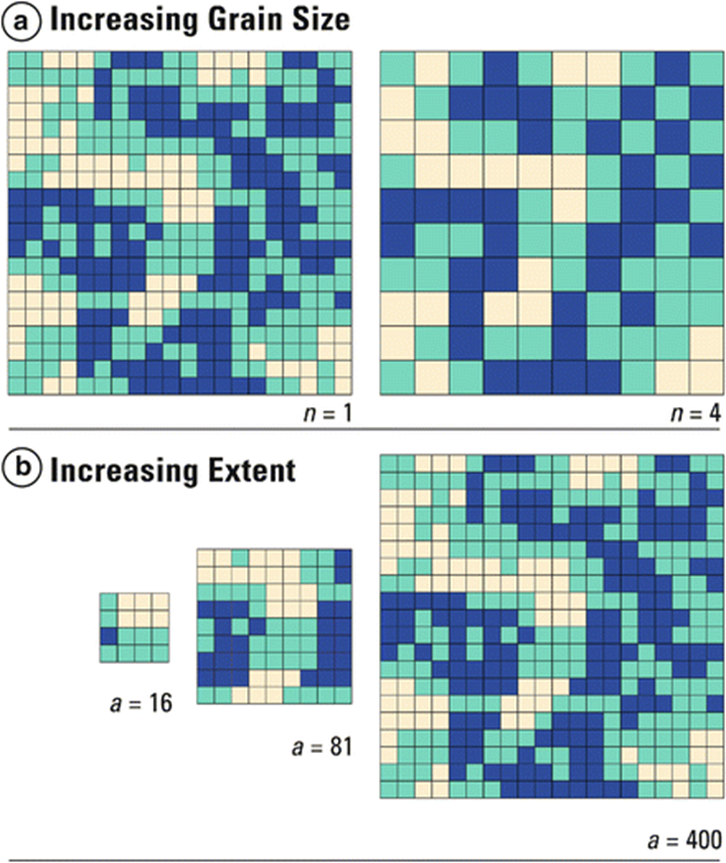

Some scientists, especially climate scientists, may “downscale” data from very coarse resolution to finer resolution using models relating variables like temperature to elevation. In other words, the grain (resolution) of global climate models are very coarse (i.e., large pixels), but data are downscaled to decrease the resolution to make the data useable for ecological or natural resource studies. See example for Alaska below.

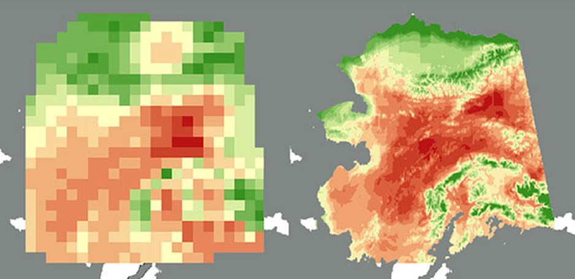

This lab will not focus on downscaling, but if you work with climate data - especially future climate predictions - you should understand some of the methods and issues related to downscaling data. While we will **not** conduct any downscaling in class, we will adjust the grain (resolution) and extent of data.

Two very common grains of spatial data are 30-meters (pixels are 30 meters by 30 meters, or about the size of the infield of a baseball diamond) or 1-km. Historically, the grain of the data increased with the extent (i.e., the larger the study area, the coarser the resolution of data). This was mostly due to computer processing limitations, but this will increasingly not be an issue. Even today, scientists work with and publish 30-meter data for the entire planet. You will find yourself in need of adjusting the resolution of data so that all data share the same resolution, to accommodate an analysis conducted at large extents, due to limitations in computer processing or time, etc.

**Coarsening the resolution of raster data (upscaling): resample and aggregate.**

Two common methods for coarsening your grain (or enlarging your resolution) are resampling or aggregating. Both of these methods are available in ArcGIS Pro and in the `terra` package in R.

If you are only interested in coarsening your data, you would probably use `aggregate()`. If you want your data to match the resolution of another existing dataset, you would probably use `resample()`.

Both functions require that you decide what kind of operation you want to use to aggregate or resample from smaller pixels to larger pixels. The most important consideration in my opinion is whether the data are categorical or quantitative. *To coarsen quantitative data, you will probably be using “bilinear interpolation” or “mean” or some other function that calculates a summary value surrounding the center of a new pixel. This results in a dataset with coarser resolution (i.e., larger pixels) that represents the central tendency of smaller pixels. To coarsen categorical data, you will most likely be using a “nearest neighbor” or “modal” operation. It does not make sense to calculate the mean of a categorical or nominal variable.*

The cartoon below show how the finer resolution input raster can be “coarsened” to a new resolution with some operation (e.g., mean, mode, max, nearest neighbor).

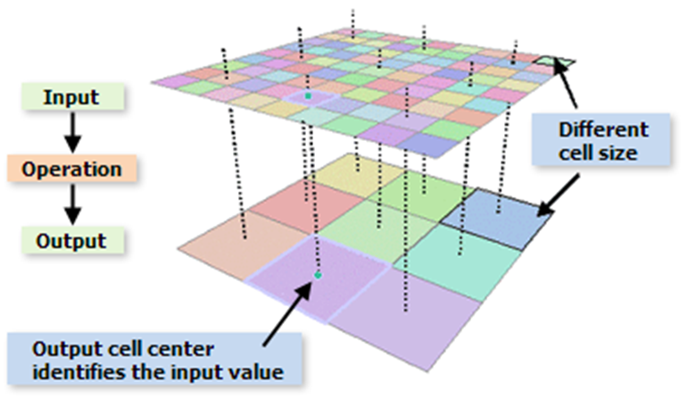

Nearest neighbor method:

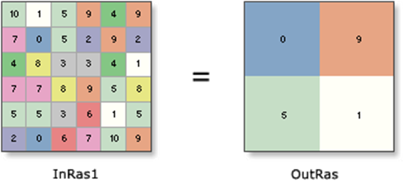

Calculating the average (mean) to coarsen the resolution:

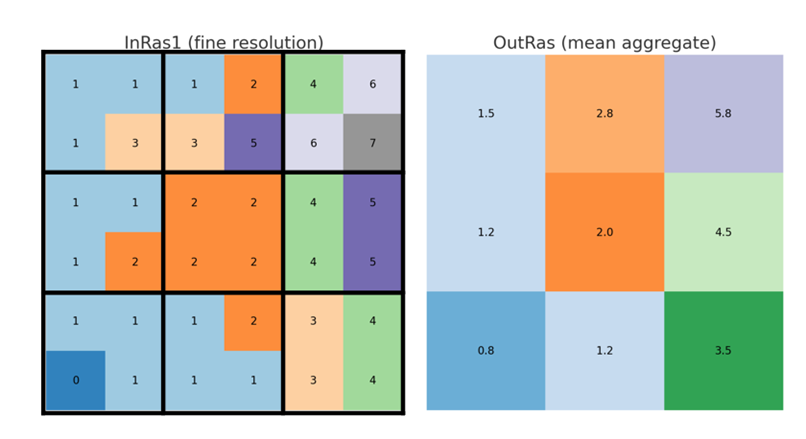

Using the maximum value:

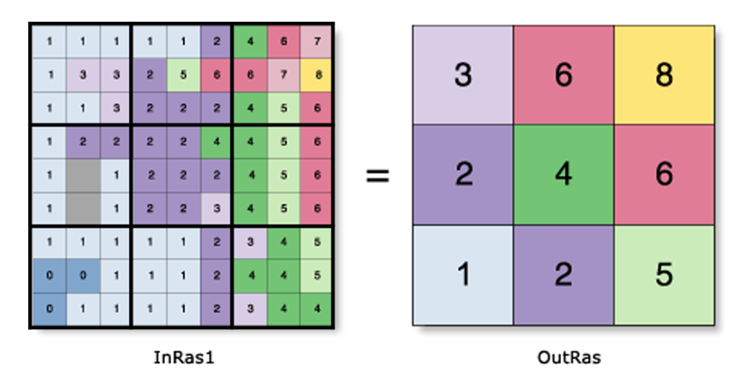

# Exercise 1: Does the landscape composition of the Greater Yellowstone Ecosystem vary with different resolutions?

We will investigate how the composition of the landscape of the GYE might depend on the resolution of the data. You will learn to “upscale” categorical raster data using the aggregate function in `terra` with the “modal” option. “Modal” means that aggregate will take the mode (i.e., the most common value) of the finer resolution data and assign that mode to the coarser resolution. Our research question is: *How does the number of land cover classes and their relative abundance change with resolution?* If you are assessing the total amount of habitat for some species, you might want to know how sensitive your analysis could be to adjustments of resolution.

First, load the `terra` and `tidyverse` libraries. If these libraries are not loaded onto your computer, use `install.packages(c("terra", "tidyverse")` first.

```r
library(terra) # for working with spatial data
library(tidyverse) # for data wrangling and plotting
```

Then, bring in the NLCD data from the GYE and plot the data, which should return a nice high resolution map of land cover for the Greater Yellowstone Ecosystem. Note: you will need to change the file path to match the location on your local machine.

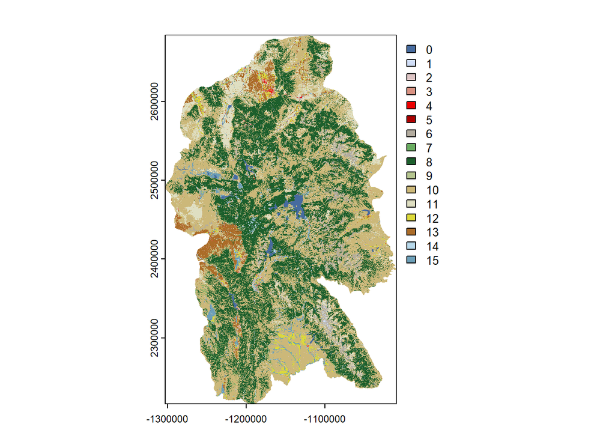

```r
# You will need to change the file path here!

nlcd_gye <- rast("Z:/Teaching/BIOE515_LandEcol_Man_Fall2025/Labs/Lab 3/Data/NLCD_2024_GYE.tif")

# look at the data
plot(nlcd_gye)
```

Then, use `res()` to check the resolution of the data and `ncell()` to see how many total pixels are in the dataset.

```r
### Analysis on 30-m data (base)
res(nlcd_gye) # double check the resolution
```

```
[1] 30 30
```

```r
ncell(nlcd_gye) # how many grid cells (pixels) are there?
```

```
[1] 152896464
```

Next, we will create a simple table of land cover types, number of pixels, and the percent of the total GYE that is in each land cover. There may be a better way to do this in R, but I will use `freq` to count the number of pixels in each land cover type. Then, I will `cats` to return the attribute table with the land cover names.

```r
freq(nlcd_gye) # this provides the count (number of pixels per class)
```

```
   layer value    count
1      1     0  1244423
2      1     1    69695
3      1     2   734688
4      1     3   712450
5      1     4   108581
6      1     5    10687
7      1     6  2582946
8      1     7   727260
9      1     8 36029052
10     1     9    10436
11     1    10 43433796
12     1    11  7937463
13     1    12  1624076
14     1    13  3414208
15     1    14  1388396
16     1    15  1882082
```

```r
cats(nlcd_gye)
```

```
[[1]]
   Value OID_1 Value_1 Pixel_Valu Red Green Blue Opacity
1     11     0       0         11  70   107  159     255
2     12     1       1         12 209   222  248     255
3     21     2       2         21 222   197  197     255
4     22     3       3         22 217   146  130     255
5     23     4       4         23 235     0    0     255
6     24     5       5         24 171     0    0     255
7     31     6       6         31 179   172  159     255
8     41     7       7         41 104   171   95     255
9     42     8       8         42  28    95   44     255
10    43     9       9         43 181   197  143     255
11    52    10      10         52 204   184  121     255
12    71    11      11         71 223   223  194     255
13    81    12      12         81 220   217   57     255
```

[output cut: 20 more lines]

We need to join these two tables together. Notice the relationship between “value” and “Value_1”; these are both unique identifiers for the rows, which allows us to “join” the table created in `cat` with the table created in `freq`.

First, we have to put those tables in a dataframe object, then use `left_join()` to merge the two dataframes. This allows us to create an easier-to-use table that has the NLCD land cover class with the count of pixels for that class.

Note: I like to use “pipes” in my code, which look like this `%>%`. This makes your code more readable, in my experience. In the first case below, the code can be read as “take nlcd_gye calculate the frequency using `freq` and then turn it into a drataframe. You could do the exact same thing like this `as.data.frame(freq(nlcd_gye))`, but I think”piping” makes things clearer by avoiding the “nested” code.

```r
# create the two dataframes
count30m <- nlcd_gye %>% freq() %>% as.data.frame()
table30m <- nlcd_gye %>% cats() %>% as.data.frame()

# join them noting that "Value_1" in table30m is the same variable as "value" in the count30m
table30m %>% left_join(count30m, by = c("Value_1" = "value"))
```

```
   Value OID_1 Value_1 Pixel_Valu Red Green Blue Opacity
1     11     0       0         11  70   107  159     255
2     12     1       1         12 209   222  248     255
3     21     2       2         21 222   197  197     255
4     22     3       3         22 217   146  130     255
5     23     4       4         23 235     0    0     255
6     24     5       5         24 171     0    0     255
7     31     6       6         31 179   172  159     255
8     41     7       7         41 104   171   95     255
9     42     8       8         42  28    95   44     255
10    43     9       9         43 181   197  143     255
11    52    10      10         52 204   184  121     255
12    71    11      11         71 223   223  194     255
13    81    12      12         81 220   217   57     255
14    82    13      13         82 171   108   40     255
```

[output cut: 19 more lines]

Let’s clean up that table by selecting only the variables of interest. Recall from Lab 2 that the relative proportion of different ecological types or land cover classes is a straightforward way to assess the composition of landscapes.

```r
table30m %>% left_join(count30m, by = c("Value_1" = "value")) %>%
  mutate(pct = count/sum(count)*100) %>%
  dplyr::select(NLCD_Land, pct)
```

```
                      NLCD_Land         pct
1                    Open Water  1.22109713
2            Perennial Ice/Snow  0.06838861
3         Developed, Open Space  0.72091677
4      Developed, Low Intensity  0.69909560
5   Developed, Medium Intensity  0.10654572
6     Developed, High Intensity  0.01048668
7                   Barren Land  2.53453041
8              Deciduous Forest  0.71362800
9              Evergreen Forest 35.35371161
10                 Mixed Forest  0.01024038
11                  Shrub/Scrub 42.61965866
12         Grassland/Herbaceous  7.78868059
13                  Pasture/Hay  1.59363379
14             Cultivated Crops  3.35021096
15               Woody Wetlands  1.36237145
16 Emergent Herbaceous Wetlands  1.84680364
```

Now that we’ve assessed the composition of the landscape using the 30-meter data, let’s use `aggregaget()` to coarsen the data (i.e., increase the size of the pixels and decrease the number of pixels) to see how our assessment of landscape composition changes with spatial grain (or resolution). We’ll do this using a factor of 10 (increasing the size of the pixels to 300-meters), 100 (pixels = 3000-meters), and 1000 (pixels = 30,000-meters). We will use the modal function, which uses the mode (most common value or type) to assign the new pixels a land cover class.

```r
nlcd_gye10 <- aggregate(nlcd_gye, 10, fun =  "modal", na.rm = TRUE)
```

```
|---------|---------|---------|---------|
=========================================
```

```r
nlcd_gye100 <- aggregate(nlcd_gye, 100, fun =  "modal", na.rm = TRUE)
nlcd_gye1000 <- aggregate(nlcd_gye, 1000, fun =  "modal", na.rm = TRUE)
```

Let’s look at the land cover maps with different resolutions.

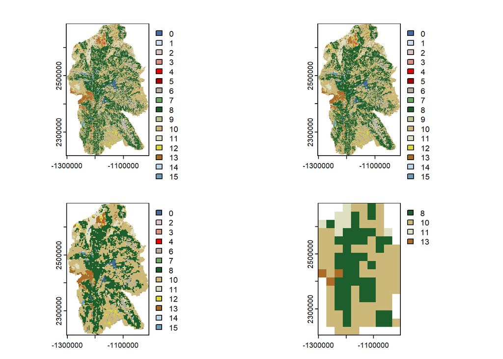

```r
# this tells R you want to create a multi-figure plot with 2 rows and 2 columns
par(mfrow = c(2, 2))

# Now, plot all four maps.
plot(nlcd_gye)
plot(nlcd_gye10)
plot(nlcd_gye100)
plot(nlcd_gye1000)
```

**TASK 1 (10 points).**

Now, repeat the steps above that we used for the original 30-meter dataset and report the (1) resolution, (2) number of pixels, (3) percent of each land cover class in the GYE based on the different resolutions. See if you can create a clean table where land cover classes are the rows and your columns are the percentages for the 4 different resolutions? You can report total pixels in a Table caption or in parentheses in the column header.

Your goal here is to make a table suitable for a paper that is clearly organized and with an informative caption. I am a fan of “stand alone” captions for figures and tables. These are captions that describe and interpret the results. Consider the consequences of coarsening the resolution. When would the coarsest map of land cover be useful? When do you absolutely need the highest resolution data? Add some of these insights to your figure caption.

# Exercise 2: Does the relationship between bird diversity and net primary productivity vary with extent and grain of analysis?

A long history of ecological research has explored the mechanisms explaining why some places host more species than others. One compelling line of research suggests that biodiversity (the number of species in an area) should be positively related to ecosystem productivity (the amount of carbon captured through photosynthesis). Some ecologists have suggested that more energy captured in highly productive areas can be divided among more species, compared to ecosystems of lower productivity. We’re going to use data on [bird species richness](https://www.sciencebase.gov/catalog/item/5bef368de4b045bfcadf73bd) and [net primary productivity](https://www.umt.edu/numerical-terradynamic-simulation-group/project/landsat/landsat-productivity.php) (NPP) to investigate these patterns for the GYE and examine whether the resolution and extent of the spatial data change our results and interpretations.

Make sure you have the `terra` and `tidyverse` packages loaded and bring the data into R.

```r
library(terra)
library(tidyverse)

# remember to change your file names to match the locations on your machine
bird   <- rast("Z:/Teaching/BIOE515_LandEcol_Man_Fall2025/Labs/Lab 3/Data/bird_richness_GYE.tif")
npp    <- rast("Z:/Teaching/BIOE515_LandEcol_Man_Fall2025/Labs/Lab 3/Data/NPP2016_GYE.tif")

# let's also bring in elevation and data on ecoregions
elev   <- rast("Z:/Teaching/BIOE515_LandEcol_Man_Fall2025/Labs/Lab 3/Data/elevation_GYE.tif")
ecoreg <- vect("Z:/Teaching/BIOE515_LandEcol_Man_Fall2025/Labs/Lab 3/Data/us_eco_l4_GYE.shp")
```

Notice that `bird`, `npp`, and `elev` (bird richness, NPP, and elevation) area all raster files (geotiffs, .tif), but `ecoreg` (ecoregions) is a vector (shapefile, .shp). Go ahead and plot `ecoreg`, which will show you the [level 4 ecoregions from the EPA](https://www.epa.gov/eco-research/level-iii-and-iv-ecoregions-continental-united-states).

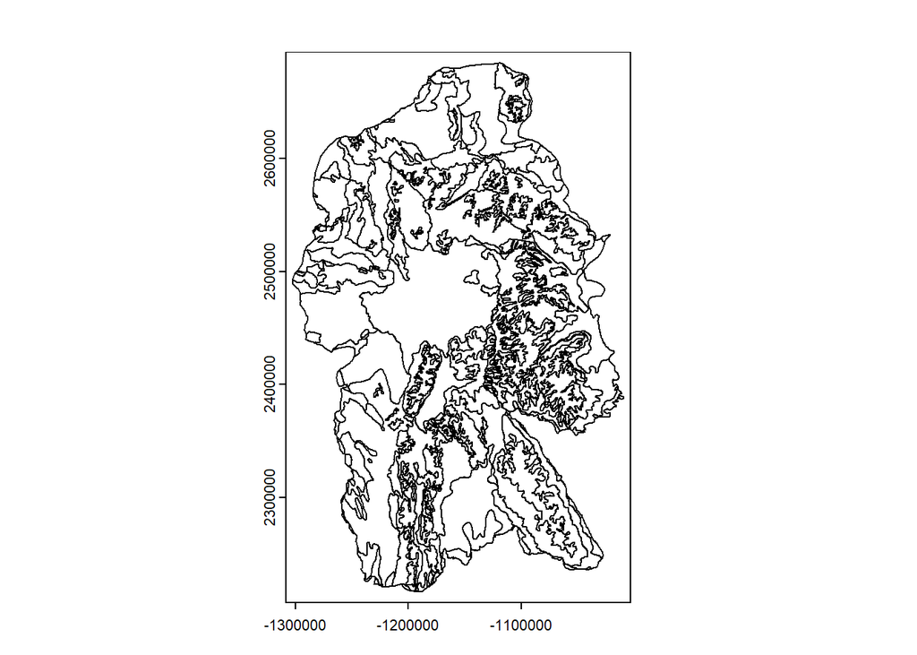

```r
plot(ecoreg)
```

We want to be able to use these data in a raster stack (which stores multiple raster layers in one R object). Raster stacks are really powerful, but you have to do some adjustments of your data before R will let you stack rasters. The adjustments include making sure that the `crs` (coordinate reference systems) and the extents are all the same. This takes some work, but it is worth it. In our case, let’s turn those ecoregions into a raster dataset. We’ll use `rasterize`, which allows you to match the raster resolution and extent to an existing raster. In this case, we’ll use elevation as our standard raster (i.e., the one with the `crs` and resolution we want the new rasters to match) and assign each pixel the variable “US_L4NAME” (the name of the level 4 ecoregion). Rasterize the data and then plot the new raster version of ecoregions for the GYE.

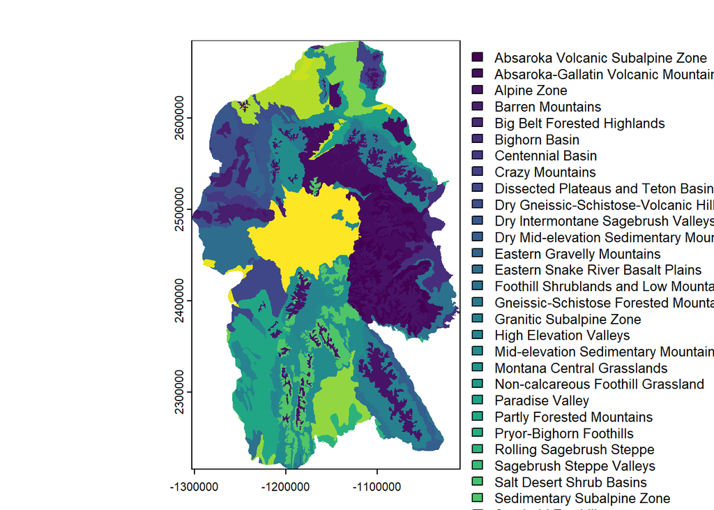

```r
ecor_gyeRast <- rasterize(ecoreg, elev, field = "US_L4NAME")
plot(ecor_gyeRast)
```

We will stack these rasters up using the well-used way to combine or concatenate `c()` data in R. Remove the `#` and run this.

```r
# Run the code below after removing the hashtag or "#" symbol.
# stack <- c(elev, bird, npp, ecor_gyeRast)
```

This should throw an error indicating that the extents do not match. Before we can stack elevation, bird richness, NPP, and ecoregion data, we’ll need to check their coordinate reference systems (`crs`) and possibly project the data into a common `crs`. ArcGIS Pro allows you to be really sloppy with this and projects layers “on the fly” without making you reproject the data. We will first check to see if the `crs` and the extent (`ext`) of each layer matches using `==` (are they equal?). We’ll use elevation as our base map.

```r
crs(elev) == crs(bird)
```

```
[1] FALSE
```

```r
crs(elev) == crs(npp)
```

```
[1] TRUE
```

```r
crs(elev) == crs(ecor_gyeRast)
```

```
[1] TRUE
```

```r
ext(elev) == ext(bird)
```

```
[1] FALSE
```

```r
ext(elev) == ext(npp)
```

```
[1] FALSE
```

```r
ext(elev) == ext(ecor_gyeRast)
```

```
[1] TRUE
```

It looks like the elevation and bird richness data do not have the same `crs` and NPP and elevation don’t have the same extent. We will use `project` to match bird richness with elevation and NPP with elevation. `project` allows you to specific how to resample the data so that the grids match perfectly. We’ll use `method = "bilinear"`, which stands for bilinear interpolation. This is a bit like averaging adjacent pixels to resample, but bilinear interpolation calculate a weighted average based on the locations of adjacent pixels. This is a very common resampling method. Notice the name I’m giving the new objects includes PRJ (this tells me that this one has been projected). This step might take some time.

```r
birdPRJ <- project(bird, elev, method = "bilinear")
```

```
|---------|---------|---------|---------|
=========================================
```

```r
nppPRJ <- project(npp, elev, method = "bilinear")
```

```
|---------|---------|---------|---------|
=========================================
```

Now, let’s try to stack these again, being careful to use the correct objects.

```r
stack <- c(elev, birdPRJ, nppPRJ, ecor_gyeRast)
```

That should’ve worked. Now, plot these to make sure things look right.

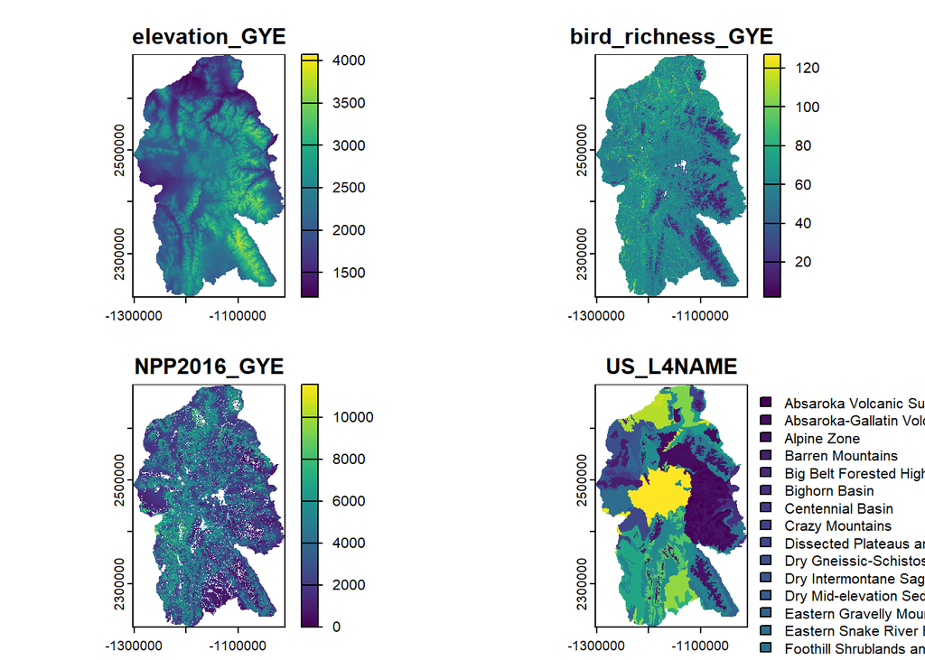

```r
plot(stack)
```

Let’s simplify the names of these layers and replot them.

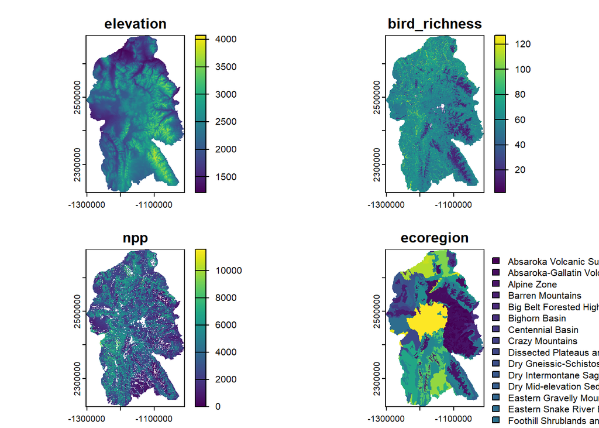

```r
names(stack) <- c("elevation", "bird_richness", "npp",  "ecoregion")
plot(stack)
```

Now we are ready to so some analysis. If you have enough RAM, you can turn this entire stack into a dataframe using something like `stackDF <- stack %>% as.data.frame(xy = T)` that will make each pixel location a row and include longitude and latitude (from `xy = T`) and each variable (elevation, bird richness, npp, and ecoregion code) as a column. This can be powerful, but it is often prudent to take a sample of your data and then do analyses. Here, we will use `spatSample` in `terra` to randomly select 5000 pixel locations and turn these into a dataframe.

```r
# take 5,000 random samples ignoring NAs, turn it into a dataframe, and add the coordinates (xy = TRUE)
stackSamp <- spatSample(stack, size = 5000, method = "random", na.rm = TRUE, as.data.frame = TRUE, xy = TRUE)

# look at the top of the dataframe
head(stackSamp)
```

```
         x       y elevation bird_richness     npp                  ecoregion
1 -1181670 2447940      2078      65.35332 5784.25        Yellowstone Plateau
2 -1228590 2336340      2033      69.56694 6967.25  Partly Forested Mountains
3 -1242390 2264430      2256      64.44005 2555.00  Partly Forested Mountains
4 -1057560 2258790      3148      41.00000 3731.75    Granitic Subalpine Zone
5 -1240230 2531100      2560      68.93655 5376.25 Eastern Gravelly Mountains
6 -1164270 2413410      2090      60.20757 5086.50     High Elevation Valleys
```

Now, let’s look the relationship between bird richness and NPP using a simple scatterplot. Notice that I am dividing NPP by 10000. I need to make this adjustment to ensure that the [units are correct](https://developers.google.com/earth-engine/datasets/catalog/UMT_NTSG_v2_LANDSAT_NPP#bands) and represent kilograms of carbon per m² per year. The developers of these data use this factor to reduce data storage requirements (i.e., storing “float” data with lots of decimals is less effecient than storing “long” integers).

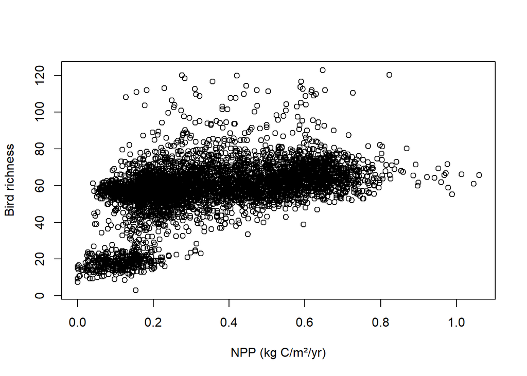

```r
# Make a scatterplot: elevation vs. NPP
plot(stackSamp$npp/10000, stackSamp$bird_richness,
     xlab = "NPP (kg C/m²/yr)",
     ylab = "Bird richness")
```

Let’s make this a nicer looking graph in ggplot.

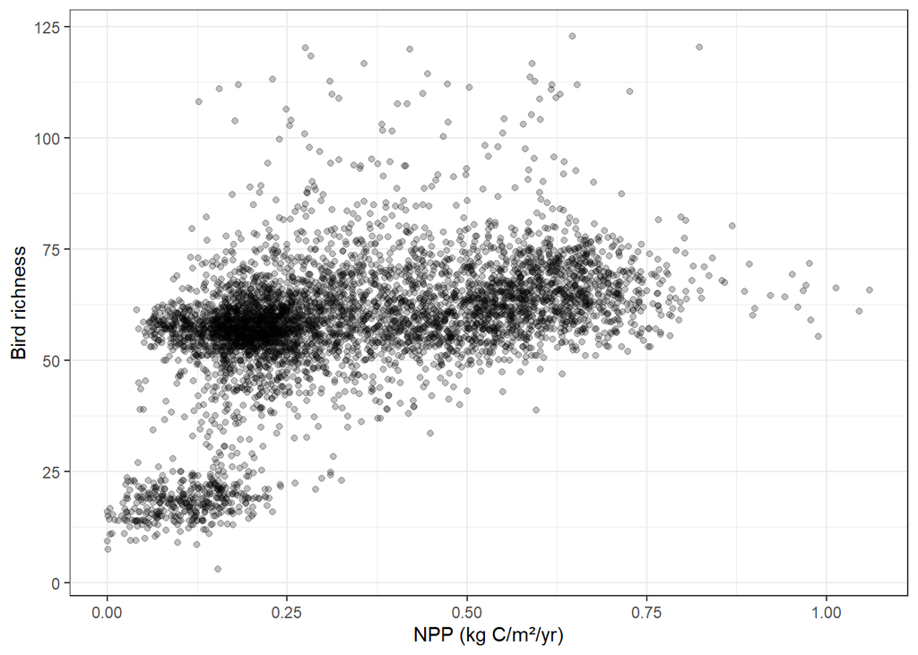

```r
stackSamp %>%  ggplot(aes(x = npp/10000, y = bird_richness)) +
  geom_point(alpha = 0.25) +
  theme_bw() +
  labs(x = "NPP (kg C/m²/yr)", y = "Bird richness")
```

Interpret the relationship between NPP and bird richness across the GYE. Do you think this relationship would change if we investigated these patterns within different ecoregions? Let’s do this by adding ecoregion as a “facet” using `facet_wrap`. This kind of data stratification (grouping your data by meaningful categories) is very easy with raster stacks in R and `ggplot2`. This is a simple way of grouping your data and subsampling a smaller geographic area. It is an ecologically meaningful way to evaluate whether your overall patterns change with extent.

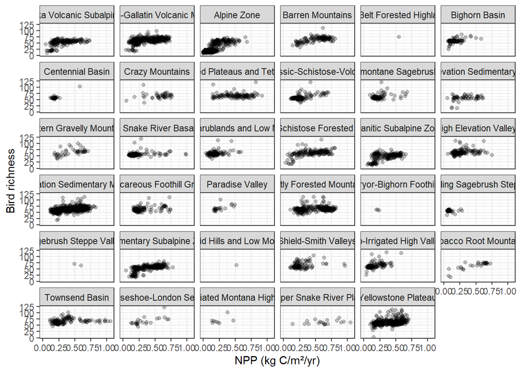

```r
stackSamp %>%  ggplot(aes(x = npp/10000, y = bird_richness)) +
  geom_point(alpha = 0.25) +
  facet_wrap(~ ecoregion) +
  theme_bw() +
  labs(x = "NPP (kg C/m²/yr)", y = "Bird richness")
```

There’s a lot to consider here, but the patterns do look different for different ecoregions. What does this tell you about the hypothesis that higher NPP supports higher bird diversity? Let’s do the same thing but using elevation as the facet (i.e., split the data into groups based on their elevation). To to this, we need to turn elevation into an ordinal variable. We will do this using `ntile`, which is a very easy way to ‘bin’ data into quantiles. In this case, let’s use 10 quantiles (i.e., deciles, which breaks the data into 10 equal-sized grounds). This takes the `stackSamp` object and adds a variable named `elev_band` that is the output of `ntile`. `mutate` is a nice function in `dplyr` that allows you to add a variable to a dataframe. An alternative might be to `stackSamp$elev_band <- ntile(stackSampe$elevation, 10)`.

```r
stackSamp <- stackSamp %>% mutate(elev_band = ntile(elevation, 10))
```

Now, let’s replot NPP and bird richness by elevation bands.

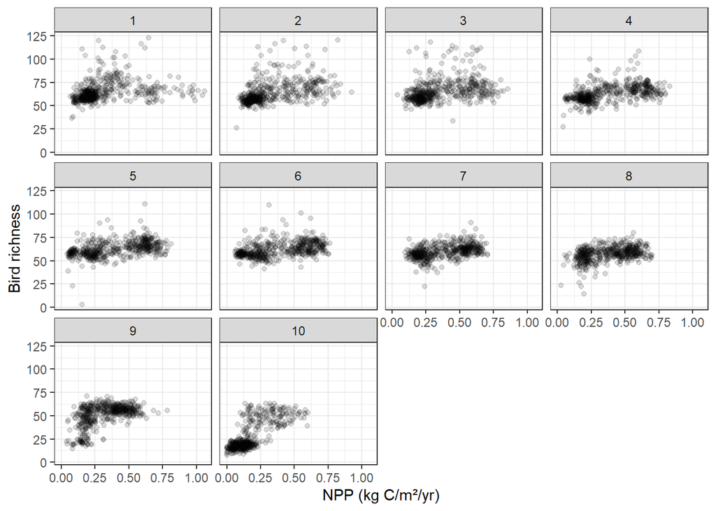

```r
stackSamp %>% ggplot(aes(x = npp/10000, y = bird_richness)) +
  geom_point(alpha = 0.15) +
  facet_wrap(~ elev_band) +
  theme_bw() +
  labs(x = "NPP (kg C/m²/yr)", y = "Bird richness")
```

Does your ecological interpretation of these patterns change with elevation? If NPP influences bird diversity, why does the relationship change with elevation?

Now, let’s look at how changing the resolution (grain) of the data might affect these patterns. Let’s drop `ecoregion` so that all variables are quantitative (and not nominal like ecoregion). We’ll do this using the bracket notation of R. We’ll create a new stack called `stack1` that selects the 1st through 3rd layers in the original stack. We can do this using `stack[[1:3]]`. This method of subsetting data can be very helpful for data processing.

```r
stack1 <- stack[[1:3]]

# look to make sure we subset the layers we meant to
names(stack1)
```

```
[1] "elevation"     "bird_richness" "npp"
```

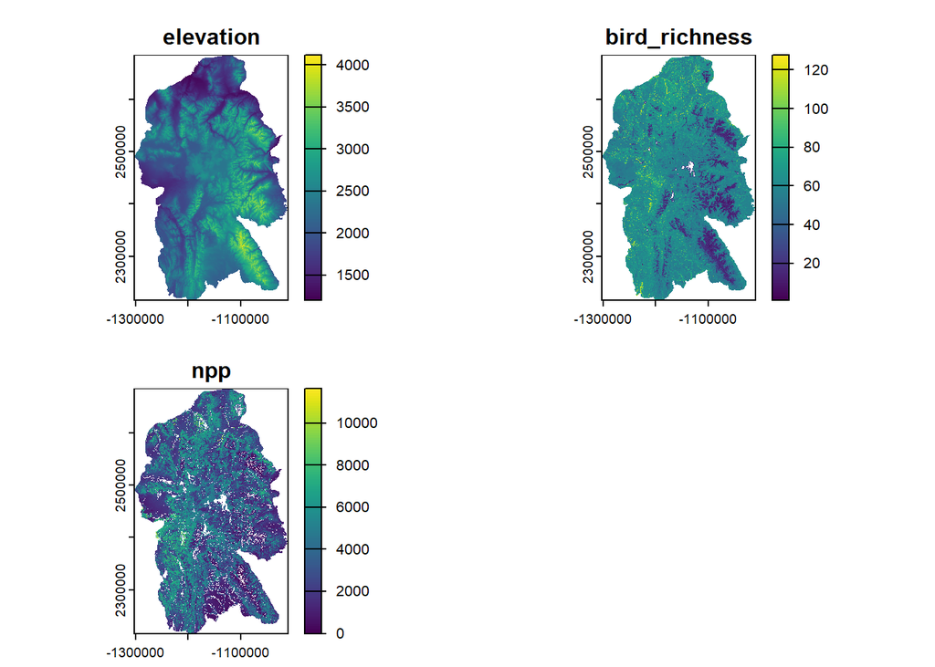

```r
plot(stack1)
```

Histograms are a really powerful and important way to visualize the distribution of the data. Histograms essentially provide a visual display of the frequency of observations for the range of values in your data. Histograms are patterns that can tell us something about processes. Are the data heavily skewed or normally distributed? What processes would give rise to a highly skewed dataset and what processes would give rise to normal data? Those questions are beyond the scope of this lab, but looking at the histograms of your data can be very revealing and is essential for doing some parametric statistical tests.

We will look at the histograms for elevation, bird richness, and NPP data and look to see how they might change with the resolution of the spatial data. We also want to look at some summary statistics like the minimum value, the maximum value, the mean, and median.

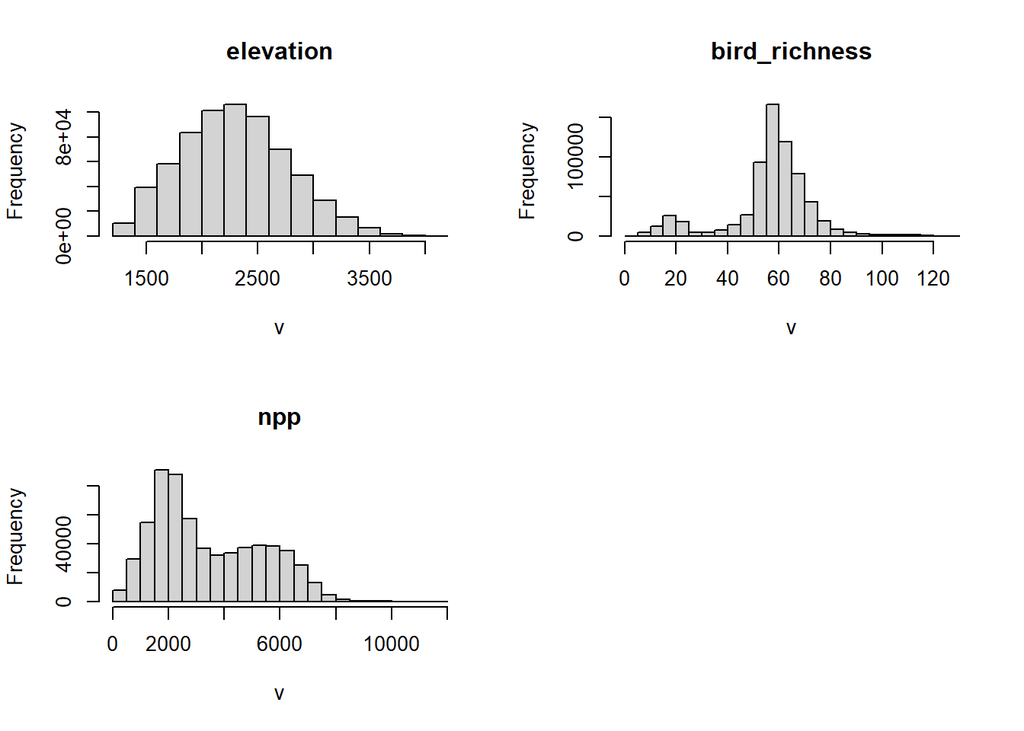

```r
# first we'll plot the histogram
hist(stack1)
```

```r
# look at the summary of values
summary(stack1)
```

```
   elevation     bird_richness         npp
 Min.   :1214    Min.   :  1.00   Min.   :    0
 1st Qu.:1949    1st Qu.: 53.42   1st Qu.: 1866
 Median :2280    Median : 58.82   Median : 2855
 Mean   :2295    Mean   : 57.07   Mean   : 3421
 3rd Qu.:2613    3rd Qu.: 65.12   3rd Qu.: 5021
 Max.   :4131    Max.   :126.82   Max.   :11460
 NA's   :33476   NA's   :33630    NA's   :37262
```

Now, let’s coarsen the resolution of the spatial data (increasing the size of pixels) using the `aggregage` function. We’ll start with the factor of 10 (`fact = 10`), which will increase the 30-meter data to 300-meter, by taking the mean of the smaller pixels using `fun = mean`, and ignore the NAs in the data using `na.rm=TRUE`. We’ll call this new stack `stk_10` to denote the factor.

```r
stk_10 <- aggregate(stack1, fact = 10, fun = mean, na.rm = TRUE)
```

```
|---------|---------|---------|---------|
=========================================
```

Now, let’s look at the maps, histograms, and summary statistics of the coarser data and compare these to the summary stats using the 30-meter data.

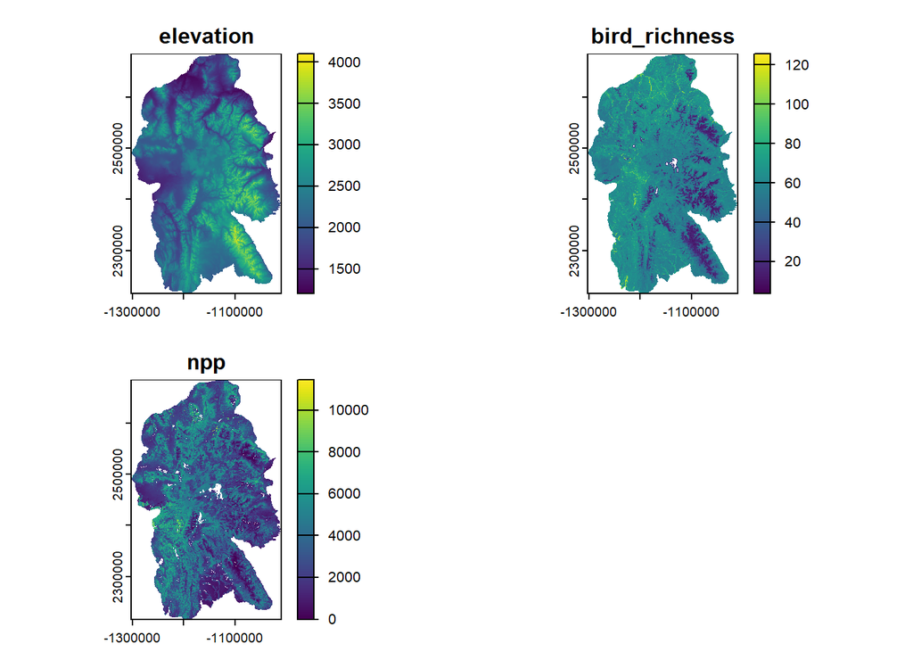

```r
# maps
plot(stk_10)
```

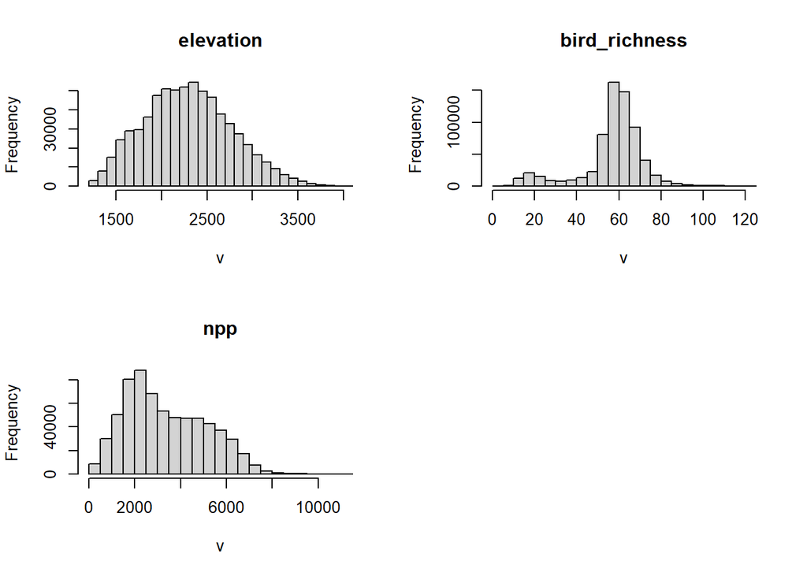

```r
# histograms
hist(stk_10)
```

```r
# summary stats
summary(stk_10)
```

```
   elevation     bird_richness         npp
 Min.   :1207    Min.   :  6.22   Min.   :    0
 1st Qu.:1949    1st Qu.: 54.05   1st Qu.: 1979
 Median :2279    Median : 59.40   Median : 3046
 Mean   :2294    Mean   : 57.06   Mean   : 3373
 3rd Qu.:2613    3rd Qu.: 64.97   3rd Qu.: 4723
 Max.   :4069    Max.   :117.72   Max.   :11304
 NA's   :33311   NA's   :33437    NA's   :34100
```

Now, let’s look to see if the relationship between NPP and bird richness changes with this change in grain.

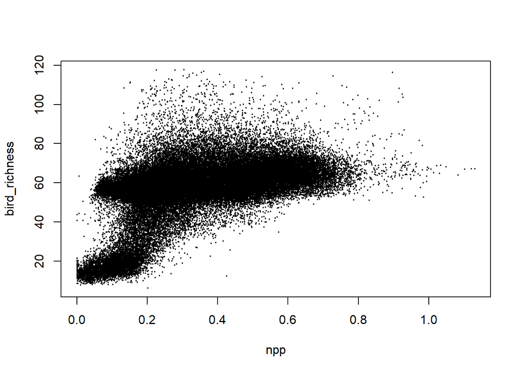

```r
plot(stk_10$npp/10000, stk_10$bird_richness)
```

Did the relationship change?

**TASK 2 (30 points).**

Change the resolution of the elevation, NPP, and bird diversity data using 2 different factors (not the ones we already used) and investigate the summary statistics, histograms, and relationship between NPP and bird richness. Organize your figures and tables, interpret the results, and write a short abstract on your findings. Please turn in your abstract (no more than 250 words, following the format in *Landscape Ecology),* as well as any figures or tables you made.